# Springboard Titanic Data Wrangling

Load Packages & Import Data

```r
library("tidyverse")

titanic_data <- read.csv("titanic_original.csv", stringsAsFactors = FALSE)
```

Preview the Data

```r
str(titanic_data)
```

```
'data.frame':   1310 obs. of  14 variables:
 $ pclass   : int  1 1 1 1 1 1 1 1 1 1 ...
 $ survived : int  1 1 0 0 0 1 1 0 1 0 ...
 $ name     : chr  "Allen, Miss. Elisabeth Walton" "Allison, Master. Hudson Trevor" "Allison, Miss. Helen Loraine" "Allison, Mr. Hudson Joshua Creighton" ...
 $ sex      : chr  "female" "male" "female" "male" ...
 $ age      : num  29 0.917 2 30 25 ...
 $ sibsp    : int  0 1 1 1 1 0 1 0 2 0 ...
 $ parch    : int  0 2 2 2 2 0 0 0 0 0 ...
 $ ticket   : chr  "24160" "113781" "113781" "113781" ...
 $ fare     : num  211 152 152 152 152 ...
 $ cabin    : chr  "B5" "C22 C26" "C22 C26" "C22 C26" ...
 $ embarked : chr  "S" "S" "S" "S" ...
 $ boat     : chr  "2" "11" "" "" ...
 $ body     : int  NA NA NA 135 NA NA NA NA NA 22 ...
 $ home.dest: chr  "St Louis, MO" "Montreal, PQ / Chesterville, ON" "Montreal, PQ / Chesterville, ON" "Montreal, PQ / Chesterville, ON" ...
```

1. Port of Embarkation: Missing values correspond to passengers who embarked from Southhampton.

Replace the missing values with “S”.

```r
titanic_data <- titanic_data %>%
  mutate(embarked = if_else(embarked == "", "S" , embarked))
```

2. Age: There are a lot of missing values in the age column.

Replace the missing values witht the mean age

```r
age_missing <- na.omit(titanic_data$age)

mean_age <- round(mean(age_missing), digits = 0)

mean_age
```

```
[1] 30
```

Age: Consider other ways to populate the missing values.

Depending on the distributon, it may make more sense to us the medain.

Create histogram

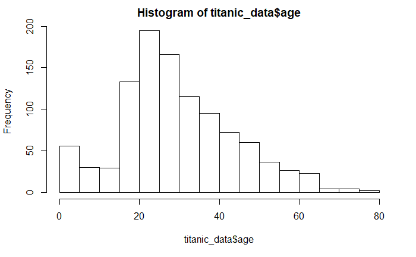

```r
hist(titanic_data$age)
```

Replace missing values with medain.

```r
median_age <- median(age_missing)

median_age
```

```
[1] 28
```

```r
titanic_data$age[is.na(titanic_data$age)] <- median_age
```

3. Lifeboat: Many passengers did not make to a lifeboat. Fill empty slots with “NA”

```r
titanic_data$boat[titanic_data$boat == ""] <- "NA"
```

4. Cabin: Many passengers don’t have passengers don’t have cabin number associated with them.

For further analysis we should fill the missing vlaues with a binary dummy values.

```r
titanic_data$cabin[titanic_data$cabin == ""] <- "NA"

cabin_has_number <- ifelse(titanic_data$cabin == "NA", 0, 1)

titanic_data$cabin_has_number <- cabin_has_number
```

5. Write clean csv file: write new csv with the cleaned up data and save it as titanic_clean.csv

```r
# view clean data

view(titanic_data)

write.table(titanic_data, "titanic_clean.csv", sep = ",")
```